# 2019 Wage Incomes in Minnesota as a Function of Race/Ethnicity and Educational Attainment

## by Brian Allan Woodcock

## Investigation Overview

This investigation looks at the interaction of race/ethnicity and educational attainment on 2019 wage incomes in Minnesota.

## Dataset Overview

The original source of the data is the 2019 American Community Survey (ACS), administered through the US Census Bureau. The 2019 ACS is a 1% sample of the US population obtained using techniques of clustering and stratification. The result is a sample with weights in order for the sample to be representative.

The data was obtained from [IPUMS USA](https://usa.ipums.org/usa/index.shtml), an online source of US Census microdata that also provides documentation and harmonization of variables across time periods. Since wage income was the focus, only people 20 years old or more were included. The resulting data set consisted of 43,143 cases (i.e., rows). For analyses concerning wage incomes, however, only employed wage earners were included in the population of interest, reducing the effective sample size (and operative data frame) to 25,597 cases. Through the use of weights, these cases were taken to be representative of 2,746,113 people in Minnesota in 2019.

## 2019 Racial/Ethnic Distribution in Minnesota

The population of people 20 years old or more in Minnesota in 2019 was about 84% White with minority populations of Blacks, Hispanics, and Asians of roughly similar sizes (approx. 5%) and a much smaller (0.8%) American Indian population.

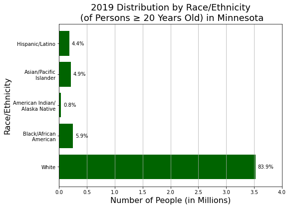

## The Distribution of Wage Income by Race/Ethnicity

Whites and Asians obtained proportionately higher wage incomes in 2019 than Blacks, Hispanics, and American Indians. It is somewhat surprising that the boxplots representing the distributions cluster into two groups by appearance. The White and Asian boxplots are very similar in structural appearance. Likewise, the Black, Hispanic, and American Indian boxplots are remarkably similar in structure. (Color coding has been used to drawn attention to this clustering.)

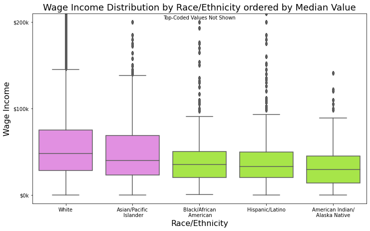

## The Impact of Educational Attainment on Wage Income

There is a positive relationship between educational attainment and wage income -- that is, increasing degress of educational attainment correspond to higher wages on average.

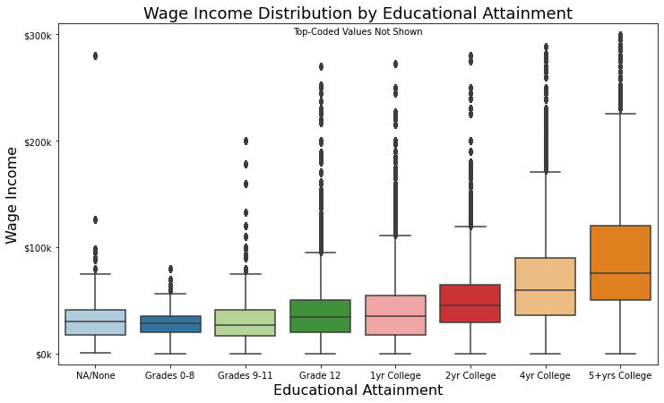

## The Distribution of Wage Income Across Educational Attainment and Race/Ethnicity

The positive relationship between educational attainment and wage income holds across the major racial/ethnic categories (although there are some local exceptions of the overall trend, to be highlighted in the next point).

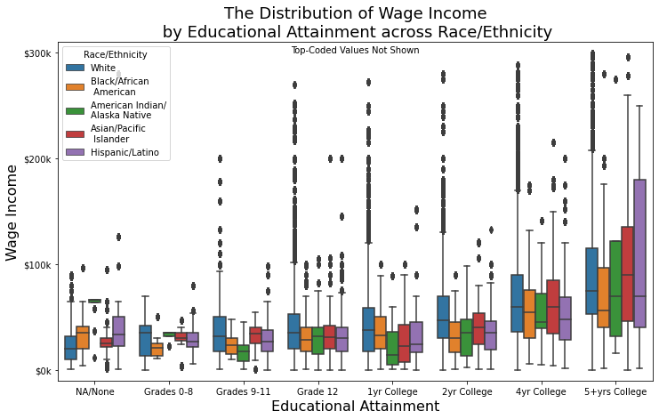

## Median Wage Incomes as a Function of Educational Attainment and Race/Ethnicity

Through the lens of looking at median wage incomes, we see again a positive relationship between educational attainment and wage income across the major racial/ethnic categories.

This global trend has some local exceptions, however.

In the graphic below, there is a global shift from lighter to darker colors across the table corresponding to increases in median wage income with increasing level of educational attainment. However, there are local exceptions to this global pattern, observable when, among a horizontal pair of adjacent blocks, the right one is lighter than the left. For example, among American Indians, Asians, and Hispanics, compare the median incomes of people with a Grade 12 education and those whose educational accomplishment is a single year of college.

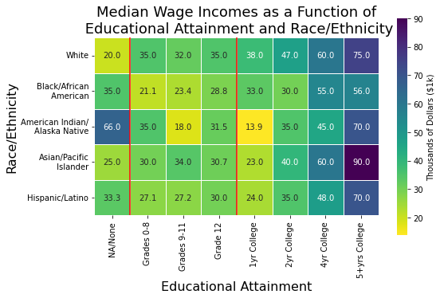

## Proportionate Distribution of Levels of Educational Attainment by Race/Ethnicity

Previously, we observed a naturally clustering of the distributions of wage income into two groups, with Whites and Asians, on one hand, and the other major racial/ethnic categories (Blacks, Hispanics, and American Indians), on the other hand.

- Is a similar natural bifurcation observable in the proportionate distribution of levels of educational attainment among these racial/ethnic groups?

Yes. Roughly 43% of Whites and Asians obtained a 4 year college degree or higher, whereas, the percentage is in the low 20s for the other three major racial/ethnic groups. This is a plausible explanation of the observed clustering of wage income distributions into two camps.

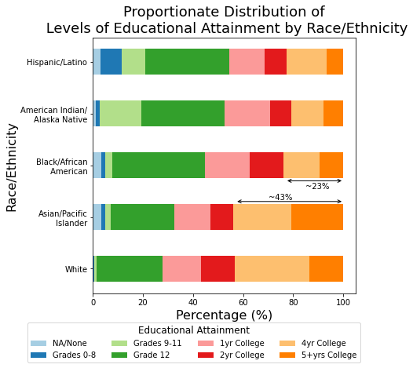